# Latihan Deploy RPubs - Analisis Nilai Pesanan Pelanggan Negara Nordic

Muhammad Bayu Nirwana

2026-03-17

```r
# Memuat paket yang diperlukan untuk koneksi database dan visualisasi
library(DBI)
library(ggplot2)
library(scales)
```

# Pendahuluan

– edited – Laporan ini menyajikan distribusi nilai pesanan (order value) yang diterima dari pelanggan di negara-negara Nordic. Proses ini mengintegrasikan SQL untuk pengambilan data dan R untuk visualisasi.

# Koneksi Database dan Pengambilan Data

Langkah pertama adalah membangun koneksi antara RStudio dan database MySQL menggunakan fungsi dbConnect()

```r
con <- DBI::dbConnect(odbc::odbc(),
                      Driver    = "MySQL ODBC 8.0 ANSI Driver",
                      Server    = "127.0.0.1",
                      Database  = "classicmodels",
                      UID       = "root",
                      PWD       = "haha", #sesuaikan dg password masing-masing
                      Port      = 3306)
```

```r
# Mendapatkan data yang diperlukan
dt1 <- dbGetQuery(con, "SELECT
    o.orderNumber,
    c.country,
    SUM(od.quantityOrdered * od.priceEach) AS total_value
FROM orders o
JOIN orderdetails od ON o.orderNumber = od.orderNumber
JOIN customers c ON o.customerNumber = c.customerNumber
WHERE c.country IN ('Denmark', 'Finland', 'Norway', 'Sweden')
GROUP BY o.orderNumber")

dt1
```

```
##    orderNumber  country total_value
## 1        10103   Norway    50218.95
## 2        10105  Denmark    53959.21
## 3        10112   Sweden     7674.94
## 4        10141  Finland    29716.86
## 5        10151  Finland    32723.04
## 6        10155  Finland    37602.48
## 7        10158   Norway     1491.38
## 8        10161  Denmark    36164.46
## 9        10167   Sweden    44167.09
## 10       10181 Norway      55069.55
## 11       10188 Norway      29954.91
## 12       10238  Denmark    28211.70
## 13       10239  Finland    16212.59
## 14       10247  Finland    28394.54
```

[output cut: 18 more lines]

# Visualisasi: Histogram Nilai Pesanan

Kita menggunakan Library ggplot2 untuk membuat histogram. Fungsi geom_histogram() digunakan untuk melihat distribusi frekuensi dari data total value.

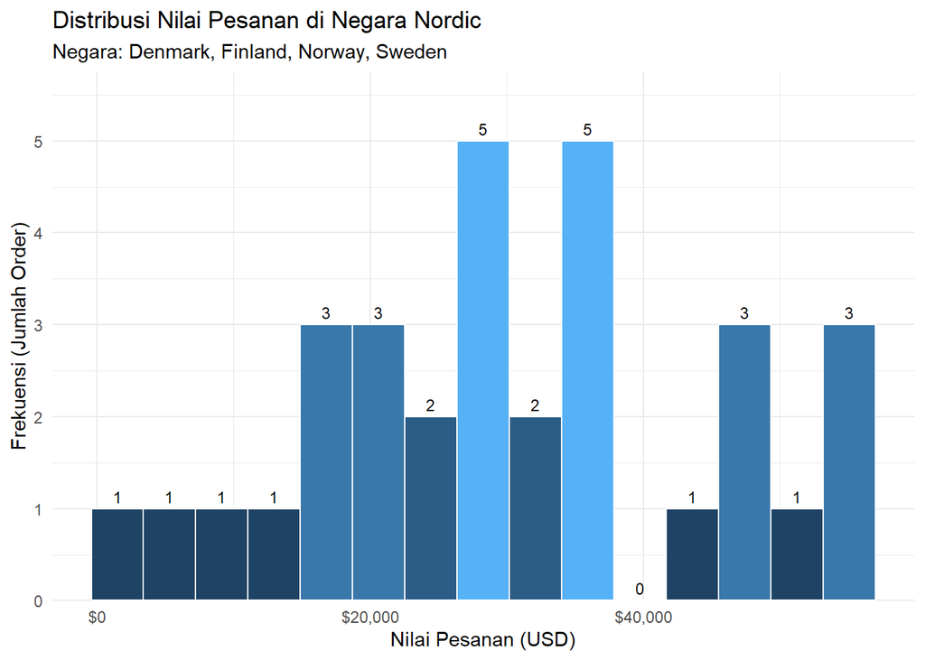

```r
# Membuat histogram dengan label yang informatif menggunakan labs()

ggplot(dt1, aes(x = total_value)) +
  geom_histogram(aes(fill = after_stat(count)), bins = 15, color = "white") +
  stat_bin(bins = 15, geom = "text", aes(label = after_stat(count)), vjust = -0.5, size = 3) +
  scale_fill_gradient(low = "#132B43", high = "#56B1F7") +
  scale_x_continuous(labels = label_dollar()) +
  scale_y_continuous(expand = expansion(mult = c(0, 0.15))) +
  theme_minimal() +
  labs(title = "Distribusi Nilai Pesanan di Negara Nordic",
       subtitle = "Negara: Denmark, Finland, Norway, Sweden",
       x = "Nilai Pesanan (USD)",
       y = "Frekuensi (Jumlah Order)") +
  theme(legend.position = "none")
```

Ini adalah contoh paragraf dengan perataan teks **justify**. Perataan ini membuat teks sejajar di kedua sisi, memberikan tampilan yang lebih rapi dan profesional, terutama dalam dokumen panjang atau artikel.

# Menampilkan rumus di R-Markdown

Dokumen R-Markdown dapat mengakomodasi penulisan persamaan matematis *(mathematical equation)*. Misal membuat rumus rata-rata sebagai berikut: $\bar{x} = \frac{\sum_{i=1}^{n} x_i}{n}$.

Persamaan matematis dapat ditampilkan secara sejajar *(inline)* seperti yang dituliskan sebelumnya. Dapat pula disajikan dalam format display seperti berikut ini:
$$\bar{x} = \frac{\sum_{i=1}^{n}
x_i}{n}$$

$$\bar{x} = \frac{1}{n} \sum_{i=1}^n
x_i$$
$\bar{x}$

$$\bar{x} = \frac{1}{n} \sum_{i=1}^n
x_i$$
$$x^{23}$$

$$x_{12}$$